# Statistical Analysis and Visualisations

Juweria Ali

2022-04-14

#### Set working directory

```r
setwd("C:/Users/juwer/Desktop/MSc/Projects/Professional Development and Research Skills/Mini Projects/Part2")
```

#### Loading libraries

```r
library(ggplot2)
library(dplyr)
```

#### Loading the dataset

```r
df = read.csv("transactions.csv", stringsAsFactors = T)

summary(df)
```

```
##        id             status       device       recipient       value
##  Min.   :  1.0   Existing:422   mobile:264   bill    :147   Min.   :  0.02
##  1st Qu.:150.8   New     :178   PC    :133   purchase:308   1st Qu.: 17.18
##  Median :300.5                  tablet:203   self    : 52   Median : 51.98
##  Mean   :300.5                               transfer: 93   Mean   : 96.24
##  3rd Qu.:450.2                                              3rd Qu.:140.27
##  Max.   :600.0                                              Max.   :568.18
##       time           model1          model2
##  Min.   : 67.0   Min.   :65.60   Min.   :68.20
##  1st Qu.:144.8   1st Qu.:77.00   1st Qu.:78.80
##  Median :178.0   Median :80.15   Median :82.30
##  Mean   :184.2   Mean   :79.97   Mean   :82.07
##  3rd Qu.:214.0   3rd Qu.:82.80   3rd Qu.:85.50
##  Max.   :517.0   Max.   :92.10   Max.   :97.30
```

### Section 1: Visualisations and Summary Statistics

#### Square root of the observations for setting the bins

```r
round(sqrt(dim(df)[1]),0)
```

```
## [1] 24
```

#### 1.1 Histogram plot showing the distribution of the values for model2

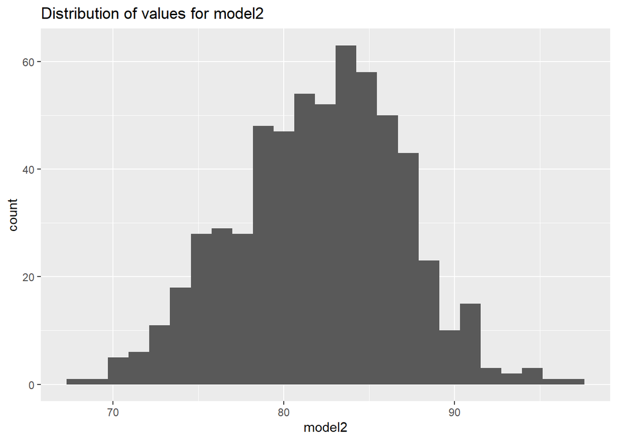

```r
ggplot(data = df , aes(x=model2))+geom_histogram(bins=25) + ggtitle("Distribution of values for model2")
```

#### Calculating the mean, median

```r
paste("model2")
```

```
## [1] "model2"
```

```r
paste("Mean =",mean(df$model2))
```

```
## [1] "Mean = 82.0713333333333"
```

```r
paste("Median =",median(df$model2))
```

```
## [1] "Median = 82.3"
```

#### Comments

From the histogram above we can see that model2 shows approximately a normal distribution which is also evident from the mean and median values calculated which are almost the same i.e ~ 82.

#### 1.2 Histogram plot showing the distribution of the values for value

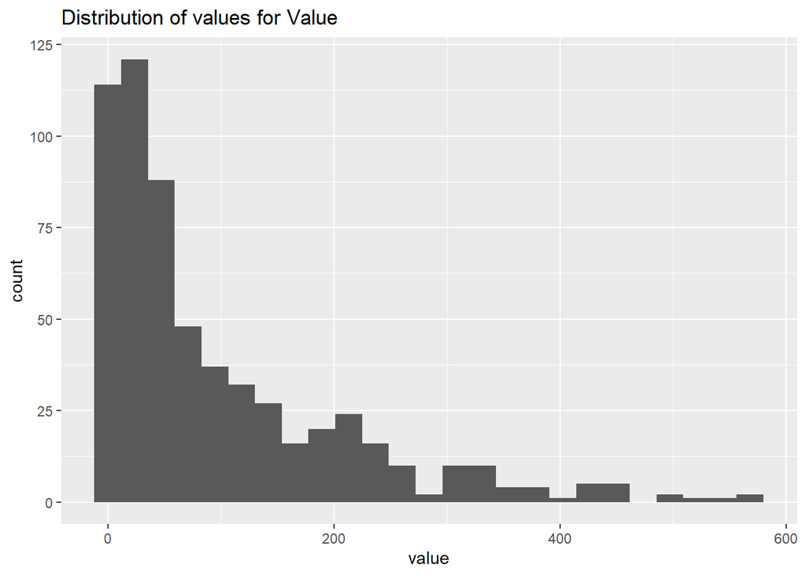

```r
ggplot(data = df , aes(x=value))+geom_histogram(bins=25) + ggtitle("Distribution of values for Value")
```

#### Calculating the mean, median

```r
paste("value")
```

```
## [1] "value"
```

```r
paste("Mean =",mean(df$value))
```

```
## [1] "Mean = 96.2421333333333"
```

```r
paste("Median =",median(df$value))
```

```
## [1] "Median = 51.985"
```

#### Comments

The histogram above for value does not show a normal distribution. It is right skewed.The mean and median values calculated also make it evident as the lie to the right of the peak.

#### 1.3 Boxplot of the value variable split by the recipient category

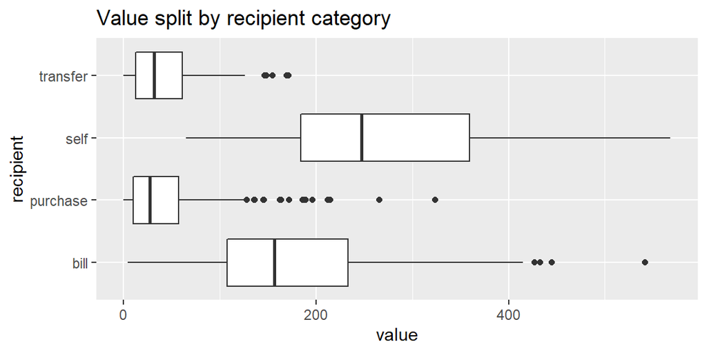

```r
ggplot(data=df, aes(y=recipient,x=value)) + geom_boxplot() + ggtitle("Value split by recipient category")
```

#### Comment critically on dependence of value on recipient:

- The highest values are for recipients of type self followed by bills.
- Purchases and transfer values are typically lower.

#### Calculate statistics of value for each recipient category

```r
summarise(group_by(df,recipient), means= mean(value), stddev=sd(value))
```

```
## # A tibble: 4 x 3
##   recipient means stddev
##   <fct>     <dbl>  <dbl>
## 1 bill      178.   103.
## 2 purchase   42.4   46.6
## 3 self      278.   135.
## 4 transfer   43.2   41.5
```

#### Comments

The values of mean and standard deviation above suggest that recipient type bill and self are more spread out whereas purchase and transfer are condensed.

#### 1.4 Scatterplot of time against value with the points colour coded according to the device

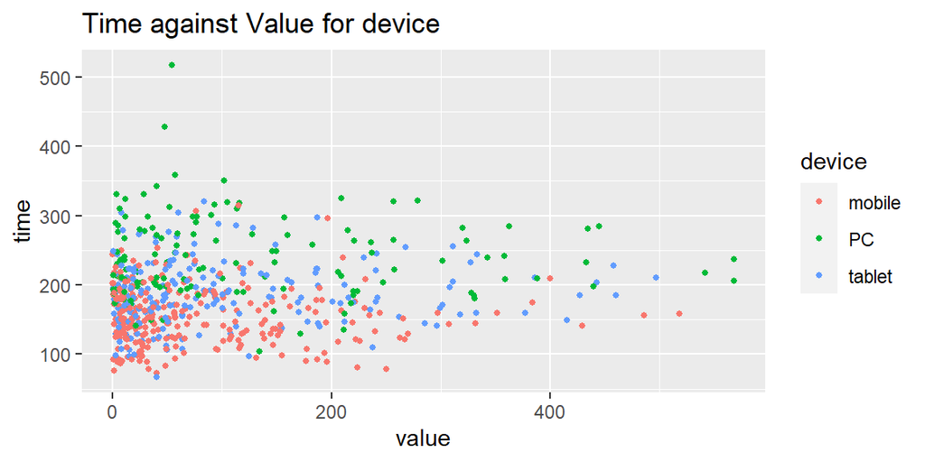

```r
ggplot(data = df,aes(x=value, y= time))+
 geom_point(size=1,shape =19,aes(colour = device))+
  labs(title ='Time against Value for device', x="value",y="time", colour="device")
```

#### Calculating the correlation of value and time

```r
cor(df$value,df$time , method ="spearman")
```

```
## [1] 0.108048
```

#### 1.5 Two stacked barplots, one with the frequencies of device against status (and the other vice versa)

#### a) Frequency of device against status

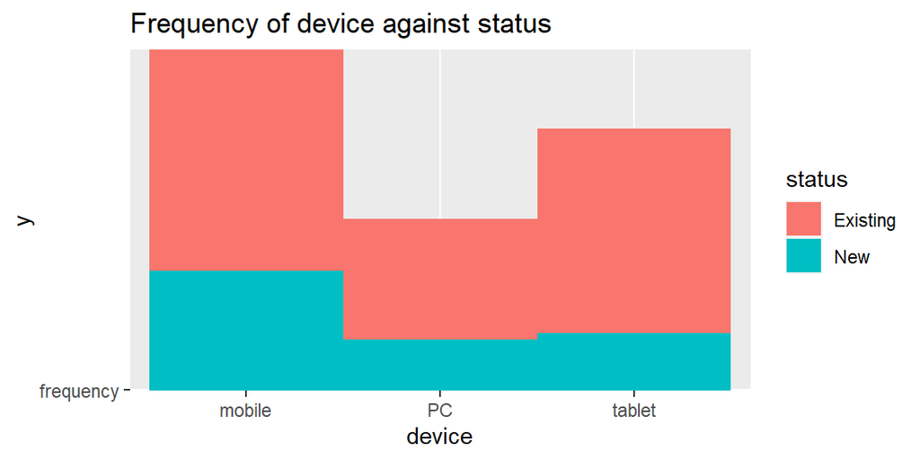

```r
ggplot(df, aes(x=device,y="frequency", fill = status)) +
  geom_bar(width= 1, stat="identity", position="stack") + ggtitle("Frequency of device against status")
```

#### b) Frequency of status against device

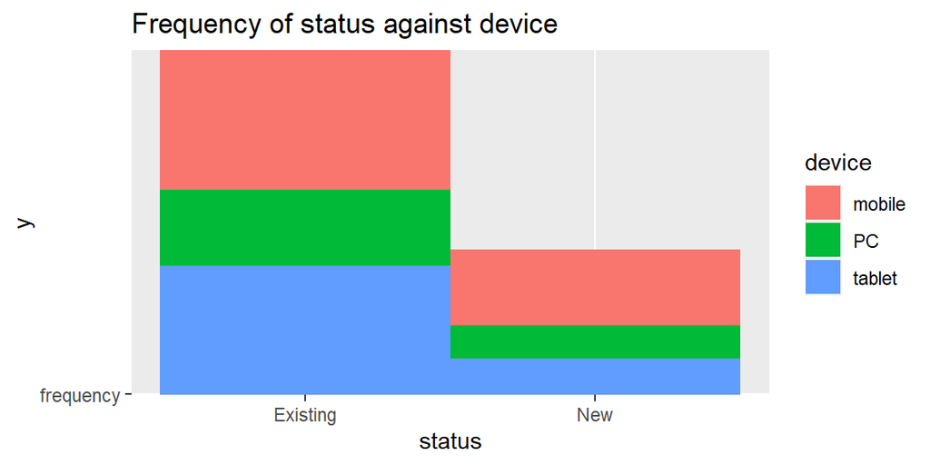

```r
ggplot(df, aes(x=status,y="frequency", fill = device)) +
  geom_bar(width= 1, stat="identity", position="stack") + ggtitle("Frequency of status against device")
```

#### Comment critically on the dependence of device and status:

- Higher rate of existing customers compared to new customers
- Higher rate of mobiles and lowest is PC

### Section 2: Tables and Measures

#### 2.1 One-way table of frequencies (counts), relative proportion and cumulative frequencies for recipient

```r
count = table(df$recipient)
count = sort(count, decr = T)
perc = 100*round(prop.table(count),3)
total = cumsum(count)
cbind(Frequency = count, Percentage = perc, Cumulative = total)
```

```
##          Frequency Percentage Cumulative
## purchase       308       51.3        308
## bill           147       24.5        455
## transfer        93       15.5        548
## self            52        8.7        600
```

#### Comments

- Most common type of online payment was made towards purchase with 51.3%
- Most rarest type of online payment was made to self with 8.7%

#### 2.2 Two-way table of recipient (in rows) and status (in columns) normalised to show the fraction of status for each recipient type

```r
tables1 <- xtabs(~ recipient+ status  , data = df)
tables1
```

```
##           status
## recipient  Existing New
##   bill          120  27
##   purchase      181 127
##   self           46   6
##   transfer       75  18
```

##### Normalising along the rows

```r
prop.table(tables1, margin=1)
```

```
##           status
## recipient   Existing       New
##   bill     0.8163265 0.1836735
##   purchase 0.5876623 0.4123377
##   self     0.8846154 0.1153846
##   transfer 0.8064516 0.1935484
```

#### Comment critically on any interesting observations

Purchase has the lowest average rate for existing recipients than others, whereas it has the highest average rate for new recipients.

#### 2.3

#### a) A table showing the mean of model2 broken down by status

```r
summarise(group_by(df,status), means = mean(model2))
```

```
## # A tibble: 2 x 2
##   status   means
##   <fct>    <dbl>
## 1 Existing  83.7
## 2 New       78.3
```

#### b) A table showing the mean of model2 broken down by device

```r
summarise(group_by(df,device), means = mean(model2))
```

```
## # A tibble: 3 x 2
##   device means
##   <fct>  <dbl>
## 1 mobile  79.7
## 2 PC      84.6
## 3 tablet  83.5
```

#### Comment critically on any interesting observations

- Existing recipients has higher means than new recipients
- PC and tablet have approximately the same means,and mobile has the lowest amongst the three.

### Section 3: Significance Tests

#### 3.1 Determine a 99% confidence interval for the mean value of model1 and model2. For each,state the mean value and the confidence interval

##### model1

```r
t.test(df$model1,mu = mean(df$model1), conf.level = 0.99)
```

```
##
##  One Sample t-test
##
## data:  df$model1
## t = 0, df = 599, p-value = 1
## alternative hypothesis: true mean is not equal to 79.97367
## 99 percent confidence interval:
##  79.51758 80.42975
## sample estimates:
## mean of x
##  79.97367
```

##### model2

```r
t.test(df$model2,mu = mean(df$model2), conf.level = 0.99)
```

```
##
##  One Sample t-test
##
## data:  df$model2
## t = 0, df = 599, p-value = 1
## alternative hypothesis: true mean is not equal to 82.07133
## 99 percent confidence interval:
##  81.55730 82.58537
## sample estimates:
## mean of x
##  82.07133
```

#### 3.2

#### a) Paired two sample t-test to test for evidence of a difference in the performance

```r
t.test(df$model2, y=df$model1,
       alternative = "two.sided",
       paired=T,
       mu= 0,
       sig.level=0.05)
```

```
##
##  Paired t-test
##
## data:  df$model2 and df$model1
## t = 11.29, df = 599, p-value < 2.2e-16
## alternative hypothesis: true difference in means is not equal to 0
## 95 percent confidence interval:
##  1.732782 2.462552
## sample estimates:
## mean of the differences
##                2.097667
```

#### Interpretation

Ho: NULL hypothesis - there is no difference in the performance between model1 and model2.

H1: Alternative hypothesis – there is a difference in the performance between model1 and model2.

Above, we see that the p value is very low than the significance level,so we reject the null hypothesis and accept the alternative hypothesis that performance is significantly different.

#### b) Performing a second t-test to assess the hypothesis that model2 outperforms model1 by a difference of 2

```r
t.test(df$model2, df$model1,
       alternative = "greater",
       paired=T,
       mu= 2,
       sig.level=0.05)
```

```
##
##  Paired t-test
##
## data:  df$model2 and df$model1
## t = 0.52567, df = 599, p-value = 0.2997
## alternative hypothesis: true difference in means is greater than 2
## 95 percent confidence interval:
##  1.791591      Inf
## sample estimates:
## mean of the differences
##                2.097667
```

#### Interpretation

Ho: NULL hypothesis - model2 does not outperform model1

H1: Alternative hypothesis – model2 outperforms model1 by a difference of 2

#### 3.3

#### a) Non-parametric test to check for evidence of reduced performance of model2 on New recipients compared to Existing recipients

```r
m1= df$model2[df$status == 'Existing']
m2= df$model2[df$status == 'New']

wilcox.test(m1,m2, paired = F,
            mu=0, exact= FALSE, alternative = "greater", sig.level=0.01)
```

```
##
##  Wilcoxon rank sum test with continuity correction
##
## data:  m1 and m2
## W = 61800, p-value < 2.2e-16
## alternative hypothesis: true location shift is greater than 0
```

#### Interpretation

Ho: NULL hypothesis - there is no difference in performance of model2 on new recipients compared to existing recipients

H1: Alternative hypothesis – there is reduced performance of model2 on new recipients compared to existing recipients

The p value is very low, so we can reject the null hypothesis and accept the alternative that there is a significant reduction in performance of model2 on new recipients compared to existing recipients.

#### b) Test to check for a difference in performance of model2 for PC device compared to tablet device

```r
m3 = df$model2[df$device == 'PC']
m4 = df$model2[df$device == 'tablet']

wilcox.test(m3,m4, paired = F,
            mu=0, exact= FALSE, alternative = "two.sided", sig.level=0.01)
```

```
##
##  Wilcoxon rank sum test with continuity correction
##
## data:  m3 and m4
## W = 14867, p-value = 0.1164
## alternative hypothesis: true location shift is not equal to 0
```

#### Interpretation

Ho: NULL hypothesis - there is no difference in performance of model2 for PC device compared to tablet

H1: Alternative hypothesis – there is difference in performance of model2 for PC device compared to tablet

The p value is higher than the significance threshold, so we can reject the alternative hypothesis and accept the null hypothesis that there is no difference in performance of model2 for PC and tablet.

#### 3.4 One-way analysis of variance with Tukey’s multiple comparisons to compare the model2 performance for different types of recipient

```r
anova1 <- aov(model2 ~ recipient, data =df)
summary(anova1)
```

```
##              Df Sum Sq Mean Sq F value Pr(>F)
## recipient     3   3676  1225.5   69.26 <2e-16 ***
## Residuals   596  10546    17.7
## ---
## Signif. codes:  0 '***' 0.001 '**' 0.01 '*' 0.05 '.' 0.1 ' ' 1
```

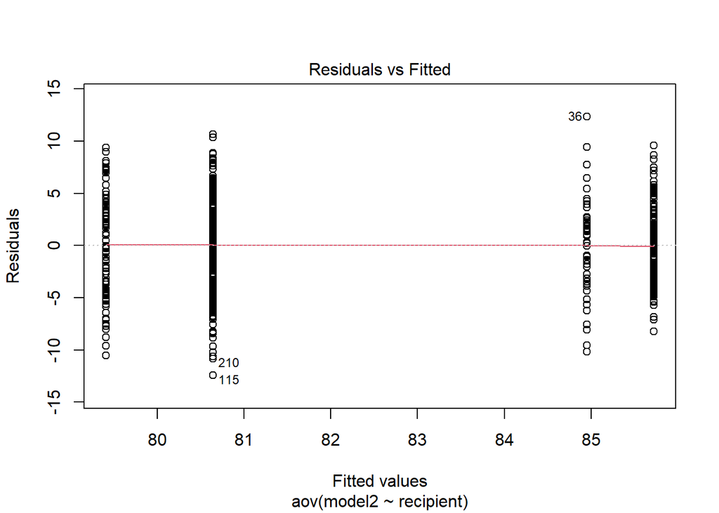

```r
plot(anova1,1)
```

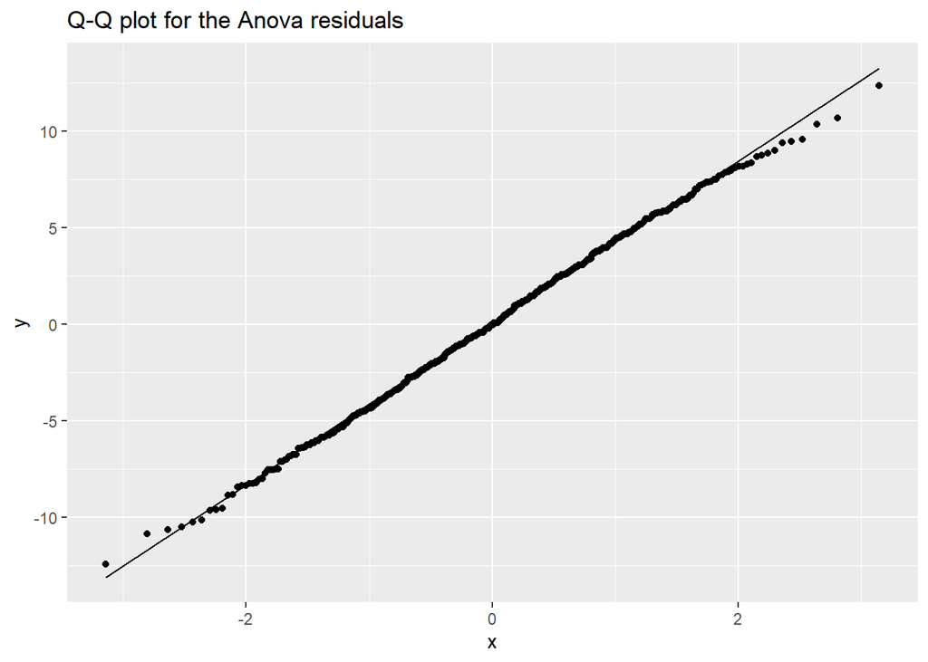

```r
res= data.frame(residuals = anova1$residuals)
ggplot(res, aes(sample = residuals)) + stat_qq() + stat_qq_line() +
  labs(title = "Q-Q plot for the Anova residuals")
```

```r
shapiro.test(anova1$residuals)
```

```
##
##  Shapiro-Wilk normality test
##
## data:  anova1$residuals
## W = 0.9984, p-value = 0.8662
```

```r
TukeyHSD(anova1, conf.level = 0.95)
```

```
##   Tukey multiple comparisons of means
##     95% family-wise confidence level
##
## Fit: aov(formula = model2 ~ recipient, data = df)
##
## $recipient
##                         diff       lwr         upr    p adj
## purchase-bill     -5.0766698 -6.163043 -3.99029680 0.000000
## self-bill         -0.7686028 -2.517134  0.97992873 0.669582
## transfer-bill     -6.3127716 -7.748634 -4.87690939 0.000000
## self-purchase      4.3080669  2.683336  5.93279804 0.000000
## transfer-purchase -1.2361018 -2.518322  0.04611844 0.063504
## transfer-self     -5.5441687 -7.420667 -3.66767063 0.000000
```

### Section 4:Experiment design, Sample sizes and Random Sampling

#### 4.1 Calculate the standard deviation of model2

```r
S = sd(df$model2)
S
```

```
## [1] 4.87267
```

#### 4.2

#### a) 2-sample t-test of statistical power 0.9 for establishing a difference of 2 in performance if a two-sided test is to be performed with significance level 0.05 and the estimated standard deviation

```r
num = ceiling(power.t.test(power = 0.9,
                           delta = 2,
                           sd = S,
                           sig.level = 0.05,
                           type = "two.sample",
                           alternative = "two.sided")$n)
num
```

```
## [1] 126
```

#### b) How large a sample would be needed to increase the power of the test to 0.99 with significance level 0.01

```r
num = ceiling(power.t.test(power = 0.99,
                           delta = 2,
                           sd = S,
                           sig.level = 0.01,
                           type = "two.sample",
                           alternative = "two.sided")$n)
num
```

```
## [1] 287
```

#### Comments

- The minimum sample size required is 126 to perform a 2-sample t-test of statistical power 0.9 for establishing a difference of 2 in performance if a two-sided test is to be performed with significance level 0.05 and the estimated standard deviation assumed to be the value calculated in task 4.1 above
- A sample of 287 would be needed to increase the power of the test to 0.99 with significance level 0.01

#### 4.3 Data frame using a random sample of size n from transactions (with no duplicates)

```r
num = 126
dfsample1 = slice_sample(df,n=num)
t= rbind(all = prop.table(table(df$recipient)),
          Random = prop.table(table(dfsample1$recipient))
        )
round(t,2)
```

```
##        bill purchase self transfer
## all    0.24     0.51 0.09     0.16
## Random 0.21     0.58 0.10     0.12
```

#### 4.4 A stratified random sample that had occurrences of recipient in the (approximately) same proportion as the transactions dataset. Create a dataframe (with no duplicates) of size n with these properties and ensure that the sample is reproducible

```r
set.seed(123)
num = 126
dfGrouped = group_by(df,recipient)
N = nrow(df)
dfsample2 = slice_sample(dfGrouped,prop=num/N)
t= rbind(all = prop.table(table(df$recipient)),
          Random = prop.table(table(dfsample1$recipient)),Stratified = prop.table(table(dfsample2$recipient))
        )
round(t,2)
```

```
##            bill purchase self transfer
## all        0.24     0.51 0.09     0.16
## Random     0.21     0.58 0.10     0.12
## Stratified 0.24     0.52 0.08     0.15
```

#### Comparing the distribution of the recipient values in the stratified sample to the complete dataset

- By setting the seed we ensure the sample is reproducible.
- The stratified sample has occurrences of recipients approximately the same, proportion wise as the complete data set.

### References

- Lonnie, D., 2022. Statistics Revision. [lab]. Professional Development and Research Skills. Robert Gordon University. School of Computing Science and Digital Media, 23rd March. Available from: https://rgu.cloud.panopto.eu/Panopto/Pages/Viewer.aspx?id=05316b5c-3837-4f30-82b5-ae6300bc8df2 [Accessed 14/04/2022].
- Lonnie, D., 2022. Statistics Revision. [lab]. Professional Development and Research Skills. Robert Gordon University. School of Computing Science and Digital Media, 23rd March. Available from: https://rgu.cloud.panopto.eu/Panopto/Pages/Viewer.aspx?id=a343dc05-912b-4c5c-a0f1-ae6300e48293 [Accessed 14/04/2022].